# Part II - Loan Dataset Presentation

## by (Olusegun Emmanuel Ajibola ) olusegunajibola.e@gmail.com

## Investigation Overview

In this presentation we visualize and summarise the different behaviours or attributes between customers who paid back their loan and customers who did not.

## Dataset Overview

This document explores a dataset containing outcomes and attributes for approximately 18,000 loan application. Our objective is to understand and summarise the different behaviours or attributes between customers who paid back their loan and customers who did not using the historical data available. The data was gotten from Lloyd's Bank Big Data Challenge. Before cleaning, we had a dataset which comprised of 18324 records and 31 features. After data cleaning, we arrived at a 15863 by 28 dataframe.

## Relationship between loan status and state address. Away from the univariate plot for the state address, this time we look at the outcome for the top 30 states.

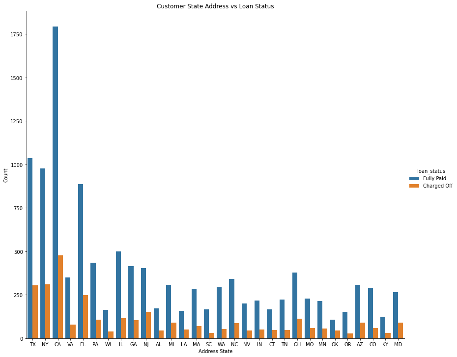

## Relationship between loan status and employment length.

Most customers with 10+ years of employment did well in paying their loans. Although they equally have more individuals who were charged off.

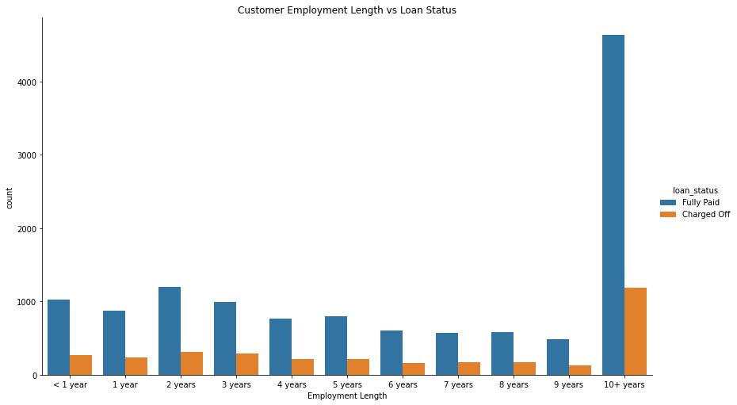

## Relationship between loan status and the interest rate on the loan and employment length.

We noticed that the interest rate distribution seems to be almost the same accross all employment length category. Again, the rate seems lower for those who paid back. We investigate this using the boxplot which shows us that those who paid back the loans did so probably because of favourable interest rate.

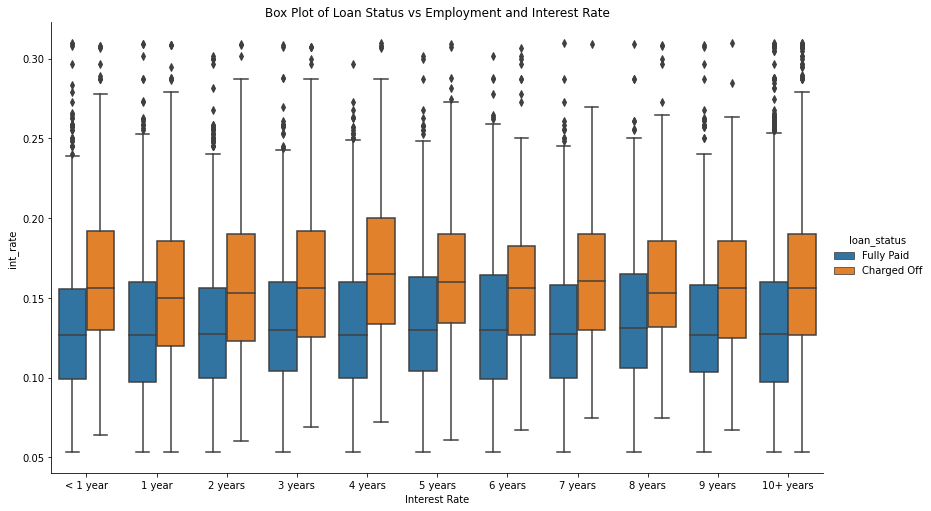

## Relationship between loan status, tenor and annual income.

Again, we see from the dodged point plot that across the loan tenors, those who earned higher on average were able to pay back the loans.

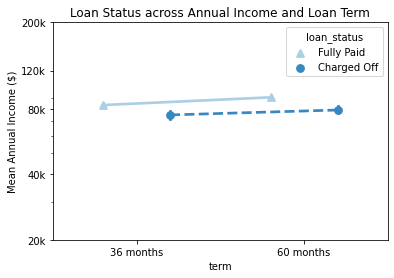